# R Notebook

```r
#load necessary libraries
library(dplyr)
library(readxl)
library(ggplot2)
library(ggpubr)
library(qqplotr)
#library(car)
library(e1071)
library(nortest)
library(BSDA)
library(psych)
library(caret)
library(leaps)
library(gvlma)
# options("scipen"=100, "digits"=6)
```

```r
# Import the csv into a dataframe
file_name = "auto-mpg.csv"
df = read.csv(file_name)
head(df)
```

|  | mpg | cylinder | displacement | horsepower | weight | acceleration | model.year | origin | car.name |
| --- | --- | --- | --- | --- | --- | --- | --- | --- | --- |
| 1 | 18 | 8 | 307 | 130 | 3504 | 12.0 | 70 | 1 | chevrolet chevelle malibu |
| 2 | 15 | 8 | 350 | 165 | 3693 | 11.5 | 70 | 1 | buick skylark 320 |
| 3 | 18 | 8 | 318 | 150 | 3436 | 11.0 | 70 | 1 | plymouth satellite |
| 4 | 16 | 8 | 304 | 150 | 3433 | 12.0 | 70 | 1 | amc rebel sst |
| 5 | 17 | 8 | 302 | 140 | 3449 | 10.5 | 70 | 1 | ford torino |
| 6 | 15 | 8 | 429 | 198 | 4341 | 10.0 | 70 | 1 | ford galaxie 500 |

# Preliminary analysis

```r
# structure of the dataframe
str(df)
```

```
'data.frame':   398 obs. of  9 variables:
 $ mpg         : num  18 15 18 16 17 15 14 14 14 15 ...
 $ cylinder    : int  8 8 8 8 8 8 8 8 8 8 ...
 $ displacement: num  307 350 318 304 302 429 454 440 455 390 ...
 $ horsepower  : chr  "130" "165" "150" "150" ...
 $ weight      : int  3504 3693 3436 3433 3449 4341 4354 4312 4425 3850 ...
 $ acceleration: num  12 11.5 11 12 10.5 10 9 8.5 10 8.5 ...
 $ model.year  : int  70 70 70 70 70 70 70 70 70 70 ...
 $ origin      : int  1 1 1 1 1 1 1 1 1 1 ...
 $ car.name    : chr  "chevrolet chevelle malibu" "buick skylark 320" "plymouth satellite" "amc rebel sst" ...
```

```r
# Converting the horsepower column to a numeric column
df$horsepower = as.numeric(df$horsepower)
head(df)
```

|  | mpg | cylinder | displacement | horsepower | weight | acceleration | model.year | origin | car.name |
| --- | --- | --- | --- | --- | --- | --- | --- | --- | --- |
| 1 | 18 | 8 | 307 | 130 | 3504 | 12.0 | 70 | 1 | chevrolet chevelle malibu |
| 2 | 15 | 8 | 350 | 165 | 3693 | 11.5 | 70 | 1 | buick skylark 320 |
| 3 | 18 | 8 | 318 | 150 | 3436 | 11.0 | 70 | 1 | plymouth satellite |
| 4 | 16 | 8 | 304 | 150 | 3433 | 12.0 | 70 | 1 | amc rebel sst |
| 5 | 17 | 8 | 302 | 140 | 3449 | 10.5 | 70 | 1 | ford torino |
| 6 | 15 | 8 | 429 | 198 | 4341 | 10.0 | 70 | 1 | ford galaxie 500 |

```r
# Summary of the dataframe
summary(df)
```

```
      mpg           cylinder      displacement     horsepower
 Min.   : 9.00   Min.   :3.000   Min.   : 68.0   Min.   : 46.0
 1st Qu.:17.50   1st Qu.:4.000   1st Qu.:104.2   1st Qu.: 75.0
 Median :23.00   Median :4.000   Median :148.5   Median : 93.5
 Mean   :23.51   Mean   :5.455   Mean   :193.4   Mean   :104.5
 3rd Qu.:29.00   3rd Qu.:8.000   3rd Qu.:262.0   3rd Qu.:126.0
 Max.   :46.60   Max.   :8.000   Max.   :455.0   Max.   :230.0
                                                 NA's   :6
     weight      acceleration     model.year        origin
 Min.   :1613   Min.   : 8.00   Min.   :70.00   Min.   :1.000
 1st Qu.:2224   1st Qu.:13.82   1st Qu.:73.00   1st Qu.:1.000
 Median :2804   Median :15.50   Median :76.00   Median :1.000
 Mean   :2970   Mean   :15.57   Mean   :76.01   Mean   :1.573
 3rd Qu.:3608   3rd Qu.:17.18   3rd Qu.:79.00   3rd Qu.:2.000
 Max.   :5140   Max.   :24.80   Max.   :82.00   Max.   :3.000

   car.name
 Length:398
 Class :character
 Mode  :character
```

*There are 6 instances where horsepower is null. We need to remove those cases.*

```r
# Removing all case with null value in any columns
df <- na.omit(df)
summary(df)
```

```
      mpg           cylinder      displacement     horsepower
 Min.   : 9.00   Min.   :3.000   Min.   : 68.0   Min.   : 46.0
 1st Qu.:17.00   1st Qu.:4.000   1st Qu.:105.0   1st Qu.: 75.0
 Median :22.75   Median :4.000   Median :151.0   Median : 93.5
 Mean   :23.45   Mean   :5.472   Mean   :194.4   Mean   :104.5
 3rd Qu.:29.00   3rd Qu.:8.000   3rd Qu.:275.8   3rd Qu.:126.0
 Max.   :46.60   Max.   :8.000   Max.   :455.0   Max.   :230.0
     weight      acceleration     model.year        origin
 Min.   :1613   Min.   : 8.00   Min.   :70.00   Min.   :1.000
 1st Qu.:2225   1st Qu.:13.78   1st Qu.:73.00   1st Qu.:1.000
 Median :2804   Median :15.50   Median :76.00   Median :1.000
 Mean   :2978   Mean   :15.54   Mean   :75.98   Mean   :1.577
 3rd Qu.:3615   3rd Qu.:17.02   3rd Qu.:79.00   3rd Qu.:2.000
 Max.   :5140   Max.   :24.80   Max.   :82.00   Max.   :3.000
   car.name
 Length:392
 Class :character
 Mode  :character
```

*This summary does not show any major problems. The gap between the means and the median are not significant. This table is telling us that any data point greater than 1.5 times IQR might be an outlier and may cause an issue for our linear regression model.Please note that even though there outliers in our data, we choose to ignore them for now.*

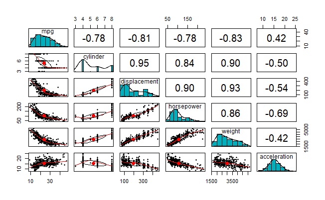

```r
# Scatter plot of matrices
pairs.panels(df[,1:6],method = "pearson",hist.col ="#00AFBB" ,density = TRUE,ellipses = TRUE)
```

*This output show three different things which are the correlation between variables, the scatter plots that tell us how the variables are associated and, the histograms the inform us how skewed our data are. We noticed that cylinder, displacement, horsepower and weight are strongly correlated and negatively correlated with the MPG. There is a multicollinearity among the independent variables. This scatter plots denote that the relationships that could be linear are the one between weight and displacement and the one between weight and horsepower, all the other are clearly not linear as they have some curve. Based on the above plots of the independent variables vs mpg, our initial assessment is to consider either weight and horsepower or weight and displacement as possible candidates for our final multi linear regression model.*

# FInding outliers using boxplot

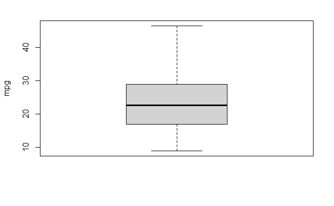

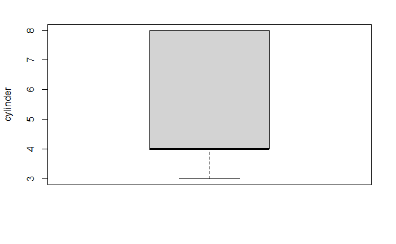

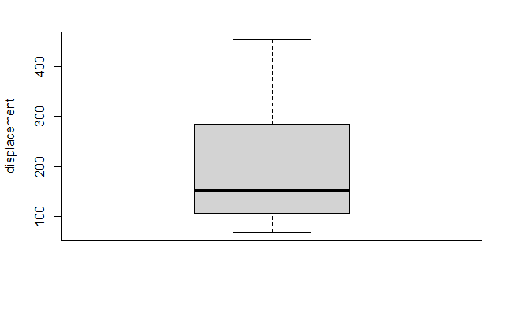

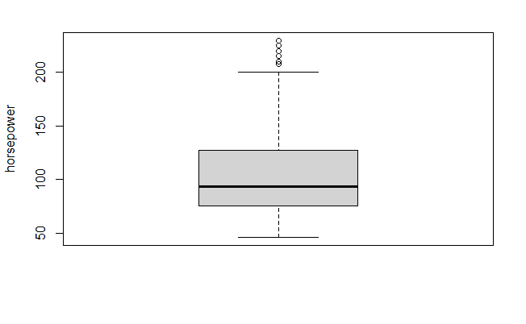

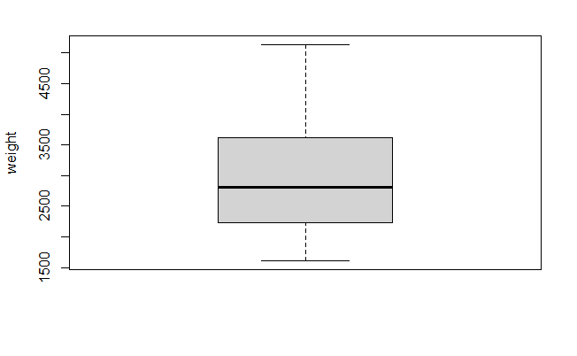

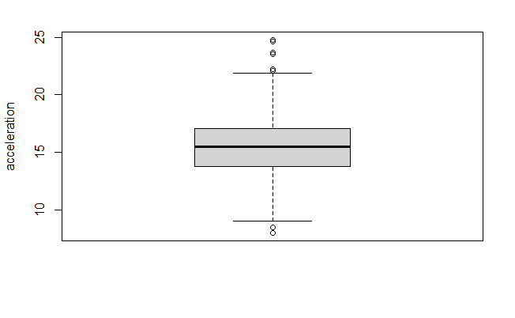

```r
for (i in names(df[,1:6])) {
  boxplot(df[,i], names = "names(df[,i])", ylab = i)
}
```

*We see some outliers for horsepower and acceleration on the above boxplots.*

## Splitting the dataset for training and testing

```r
#Using the rest 300 samples in the dataframe, run a simple linear regression to determine the relationship between mpg and a single variable
df_train <- df[1:300,1:6]
df_test <- df[301:nrow(df),1:6]
```

# Model with displacement as explanatory variable

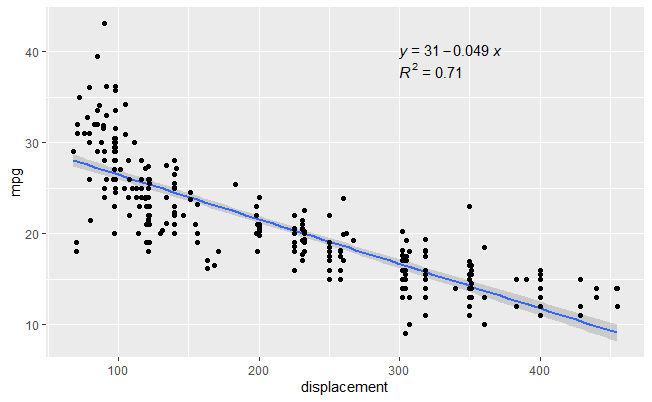

```r
# Linear regression plot
ggplot(data=df_train, aes(x=displacement, y=mpg)) +
        geom_smooth(method="lm") +
        geom_point() +
        stat_regline_equation(label.x=300, label.y=40) +
        stat_cor(aes(label=..rr.label..), label.x=300, label.y=38)
```

```r
#performing regression
dis_model <- lm(mpg~displacement, data=df_train)
summary(dis_model)
```

```
Call:
lm(formula = mpg ~ displacement, data = df_train)

Residuals:
    Min      1Q  Median      3Q     Max
-9.9282 -2.0043 -0.5401  1.9737 16.1501

Coefficients:
              Estimate Std. Error t value Pr(>|t|)
(Intercept)  31.352035   0.435875   71.93   <2e-16 ***
displacement -0.048913   0.001809  -27.04   <2e-16 ***
---
Signif. codes:  0 ‘***’ 0.001 ‘**’ 0.01 ‘*’ 0.05 ‘.’ 0.1 ‘ ’ 1

Residual standard error: 3.412 on 298 degrees of freedom
Multiple R-squared:  0.7104,    Adjusted R-squared:  0.7094
F-statistic: 731.1 on 1 and 298 DF,  p-value: < 2.2e-16
```

```r
# mean of residuals
mean(resid(dis_model))
```

```
[1] 3.035766e-16
```

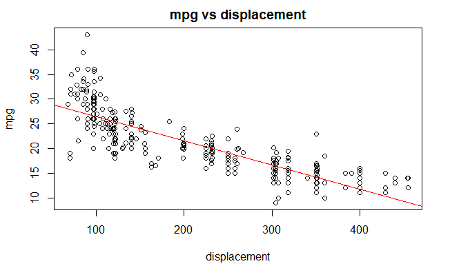

```r
#plot the variable
plot(df_train$mpg~df_train$displacement,main="mpg vs displacement",xlab="displacement",ylab = "mpg")
abline(dis_model,col="red")
```

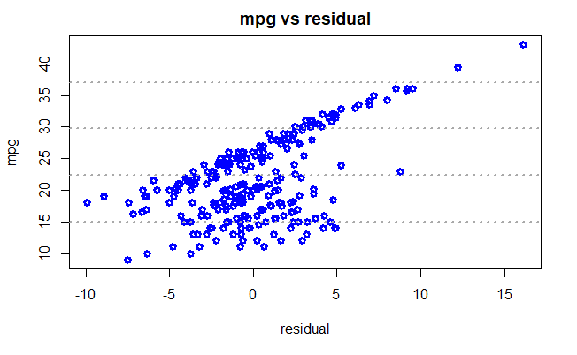

```r
#residuals vs. the predictor variable
residual <- dis_model$residuals
plot(df_train$mpg~residual,lwd=3, col="blue",main="mpg vs residual", xlab="residual",ylab = "mpg")
grid(NA, 5, lwd = 2,col = "darkgray")
```

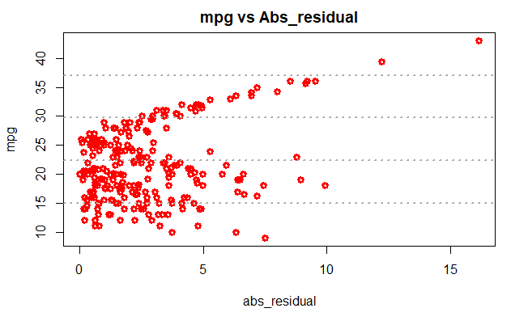

```r
#absolute value of the residuals vs. the predictor variable
abs_residual <- abs(residual)
plot(df_train$mpg~abs_residual,lwd=3, col="red",main="mpg vs Abs_residual", xlab="abs_residual",ylab = "mpg")
grid(NA, 5, lwd = 2,col = "darkgray")
```

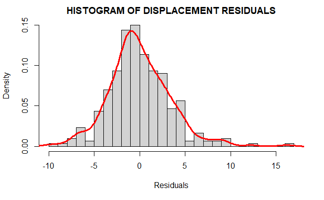

```r
#histogram of the residuals
hist(residual,prob=T,breaks=20,main="HISTOGRAM OF DISPLACEMENT RESIDUALS",xlab="Residuals")
lines(density(residual),col="red",lwd=3)
```

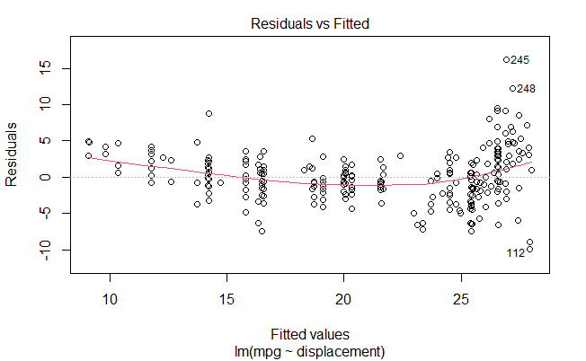

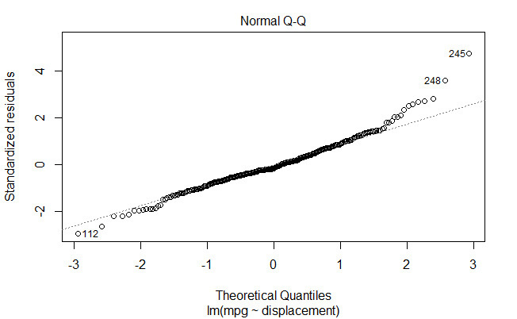

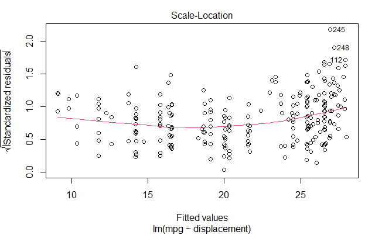

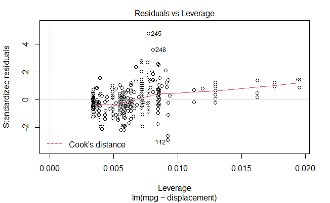

```r
plot(dis_model)
```

```r
# Make predictions and compute the R2, RMSE and MAE
dis_predict <- dis_model %>% predict(df_test)
data.frame( R2 = R2(dis_predict, df_test$mpg),
            RMSE = RMSE(dis_predict, df_test$mpg),
            MAE = MAE(dis_predict, df_test$mpg))
```

| R2 | RMSE | MAE |
| --- | --- | --- |
| 0.370789 | 8.371337 | 7.050203 |

```r
prediction_error = RMSE(dis_predict, df_test$mpg)/mean(df_test$mpg)
prediction_error
```

```
[1] 0.2620493
```

```r
compare_dis = as.data.frame(cbind(df_test$mpg,dis_predict),row=FALSE)
names(compare_dis) = c("observed","dis_predict")
head(compare_dis)
```

|  | observed | dis_predict |
| --- | --- | --- |
| 1 | 34.5 | 26.21621 |
| 2 | 31.8 | 27.19446 |
| 3 | 37.3 | 26.90099 |
| 4 | 28.4 | 23.96623 |
| 5 | 28.8 | 22.89016 |
| 6 | 26.8 | 22.89016 |

*In this model all the estimated values are statistically significant with a p-value less than 2e-16 . It is shown that the plot of MPG vs the Displacement is not linear and there is a sort of relationship between the variable and the residual. This model is definitely not the ideal one. The diagnostic plot reveal that these following data point 112,245,248 are outliers. The adjusted R-square state that 70.94% of displacement explain MPG.*

# Model with horsepower as explanatory variable

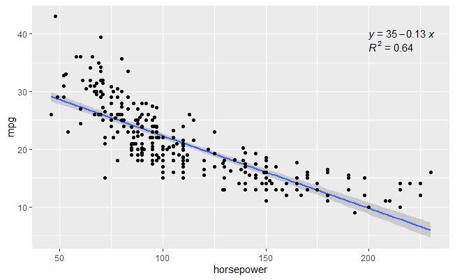

```r
# Linear regression plot
ggplot(data=df_train, aes(x=horsepower, y=mpg)) +
        geom_smooth(method="lm") +
        geom_point() +
        stat_regline_equation(label.x=200, label.y=40) +
        stat_cor(aes(label=..rr.label..), label.x=200, label.y=38)
```

```r
#performing regression
hors_model <- lm(mpg~horsepower, data=df_train)
summary(hors_model)
```

```
Call:
lm(formula = mpg ~ horsepower, data = df_train)

Residuals:
     Min       1Q   Median       3Q      Max
-10.8442  -2.7816  -0.3376   2.4948  14.2360

Coefficients:
             Estimate Std. Error t value Pr(>|t|)
(Intercept) 34.903508   0.648037   53.86   <2e-16 ***
horsepower  -0.125824   0.005455  -23.07   <2e-16 ***
---
Signif. codes:  0 ‘***’ 0.001 ‘**’ 0.01 ‘*’ 0.05 ‘.’ 0.1 ‘ ’ 1

Residual standard error: 3.8 on 298 degrees of freedom
Multiple R-squared:  0.641, Adjusted R-squared:  0.6397
F-statistic:   532 on 1 and 298 DF,  p-value: < 2.2e-16
```

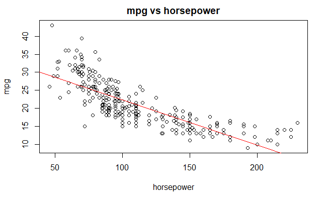

```r
#plot the variable
plot(df_train$mpg~df_train$horsepower,main="mpg vs horsepower",xlab="horsepower",ylab = "mpg")
abline(hors_model,col="red")
```

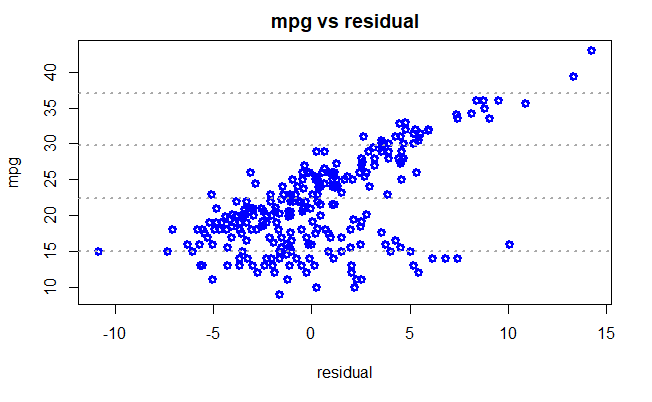

```r
#residuals vs. the predictor variable
residual <- hors_model$residuals
plot(df_train$mpg~residual,lwd=3, col="blue",main="mpg vs residual", xlab="residual",ylab = "mpg")
grid(NA, 5, lwd = 2,col = "darkgray")
```

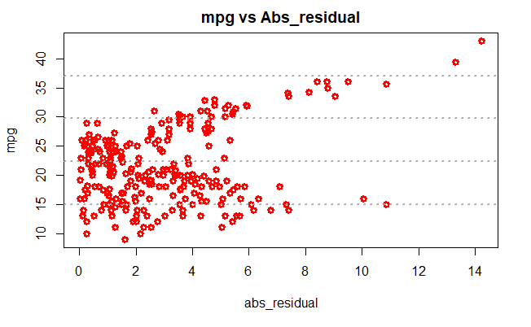

```r
#absolute value of the residuals vs. the predictor variable
abs_residual <- abs(residual)
plot(df_train$mpg~abs_residual,lwd=3, col="red",main="mpg vs Abs_residual", xlab="abs_residual",ylab = "mpg")
grid(NA, 5, lwd = 2,col = "darkgray")
```

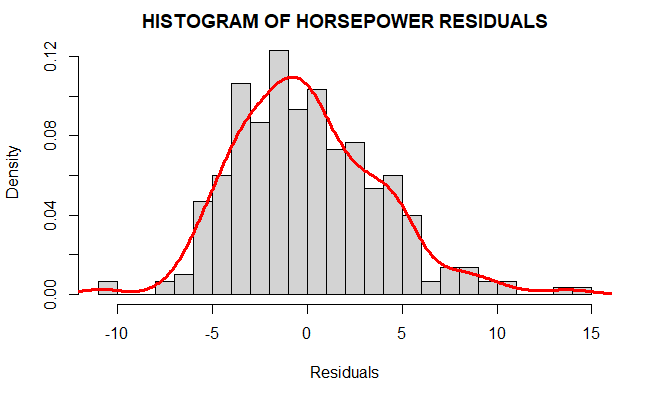

```r
#histogram of the residuals
hist(residual,prob=T,breaks=20,main="HISTOGRAM OF HORSEPOWER RESIDUALS",xlab="Residuals")
lines(density(residual),col="red",lwd=3)
```

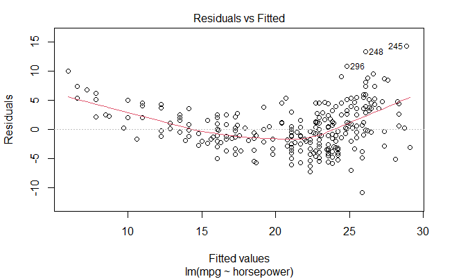

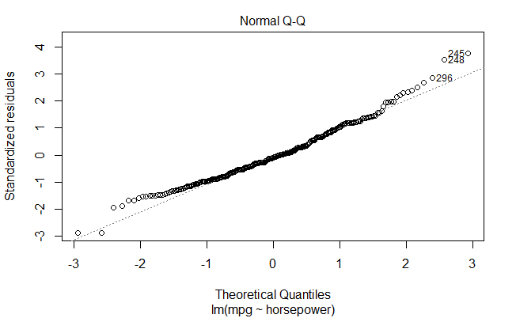

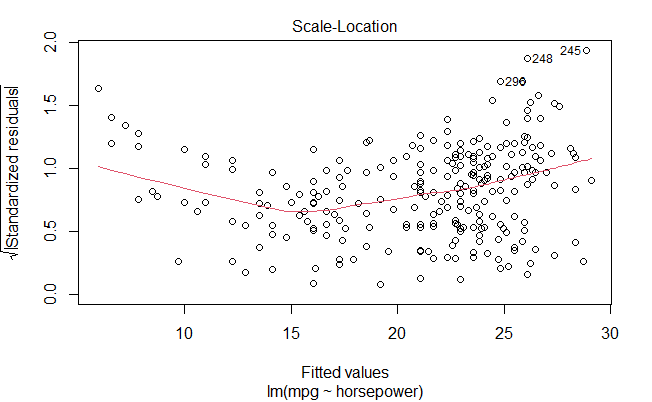

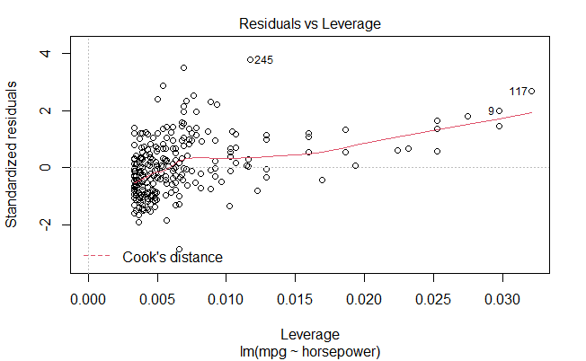

```r
plot(hors_model)
```

```r
# mean of residuals
mean(resid(hors_model))
```

```
[1] -8.257284e-17
```

```r
# Make predictions and compute the R2, RMSE and MAE
hors_predict <- hors_model %>% predict(df_test)
data.frame( R2 = R2(hors_predict, df_test$mpg),
            RMSE = RMSE(hors_predict, df_test$mpg),
            MAE = MAE(hors_predict, df_test$mpg))
```

| R2 | RMSE | MAE |
| --- | --- | --- |
| 0.4483999 | 8.592932 | 7.508721 |

```r
prediction_error = RMSE(hors_predict, df_test$mpg)/mean(df_test$mpg)
prediction_error
```

```
[1] 0.268986
```

```r
compare_hors = as.data.frame(cbind(df_test$mpg,hors_predict),row=FALSE)
names(compare_hors) = c("observed","hors_predict")
head(compare_hors)
```

|  | observed | hors_predict |
| --- | --- | --- |
| 1 | 34.5 | 26.09584 |
| 2 | 31.8 | 26.72496 |
| 3 | 37.3 | 26.22166 |
| 4 | 28.4 | 23.57936 |
| 5 | 28.8 | 20.43376 |
| 6 | 26.8 | 20.43376 |

*In this model all the estimated values are statistically significant with a p-value less than 2e-16 . It is shown that the plot of MPG vs the horsepower is not linear and there is a sort of non-linear relationship between the variable and the residual. This model is definitely not the ideal one. The diagnostic plot reveal that these following data point 245,248,296 are outliers. The adjusted R-square state that 63.97 % of horsepower explain MPG.*